# First R Markdown File

##Read in the data

```r
temp<-tempfile()
download.file("http://d396qusza40orc.cloudfront.net/repdata%2Fdata%2Factivity.zip",temp)
movement_data<- read.csv(unz(temp,"activity.csv"))
unlink(temp)
```

##What is mean total number of steps taken per day? Calculate daily total number of steps and make histogram

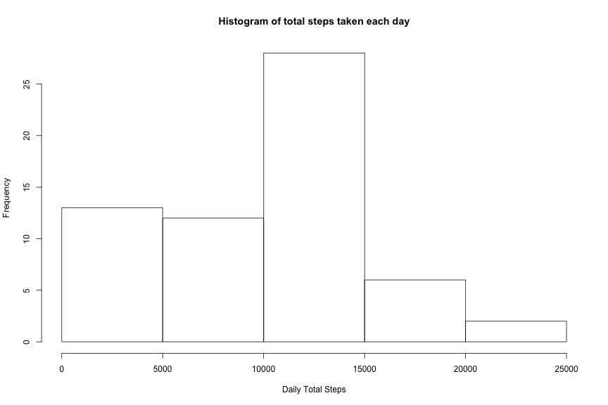

```r
library(data.table)
daily_total<-data.table(movement_data)[,list(daily_steps=sum(steps,na.rm=TRUE)),by=date]
hist(daily_total$daily_steps,main='Histogram of total steps taken each day',xlab='Daily Total Steps')
```

Calculate and report the mean and median of the total number of steps taken per day

```r
mean_daily<-mean(daily_total$daily_steps)
median_daily<-median(daily_total$daily_steps)
print(paste("The mean of the total number of steps taken per day is",round(mean_daily,digits=2)))
```

```
## [1] "The mean of the total number of steps taken per day is 9354.23"
```

```r
print(paste("The median of the total number of steps taken per day is",median_daily))
```

```
## [1] "The median of the total number of steps taken per day is 10395"
```

##What is the average daily activity pattern? Calculate steps over time intervals, averaged over days

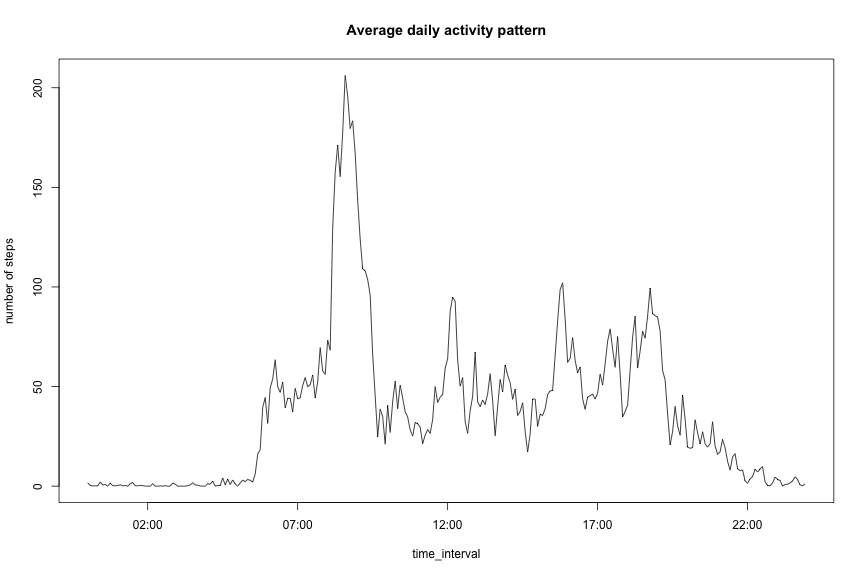

```r
interval_avg<-data.table(movement_data)[,list(interval_avg_steps=mean(steps,na.rm=TRUE)),by=interval]
library(lubridate)
time_interval<-fast_strptime(sprintf("%04d", interval_avg$interval), "%H%M")
plot(x=time_interval,y=interval_avg$interval_avg_steps,type='l',main='Average daily activity pattern',ylab='number of steps')
```

```r
most_active<-interval_avg[which.max(interval_avg$interval_avg_steps),]
print(paste("The most active time intertval is",most_active$interval))
```

```
## [1] "The most active time intertval is 835"
```

##Imputing missing values Calculate the total number of missing values in the dataset

```r
num_mis=sum(is.na(movement_data$steps))
print(paste("The number of missing values is",num_mis))
```

```
## [1] "The number of missing values is 2304"
```

Impute the average of the time interval and create new_movement_data

```r
mer<-merge(movement_data,interval_avg,by="interval")
non_miss<-transform(mer, steps= ifelse(is.na(steps), interval_avg_steps,steps))
new_movement_data<-non_miss[order(non_miss$date,non_miss$interval),1:3]
```

Repeat the daily total histogram and mean/median

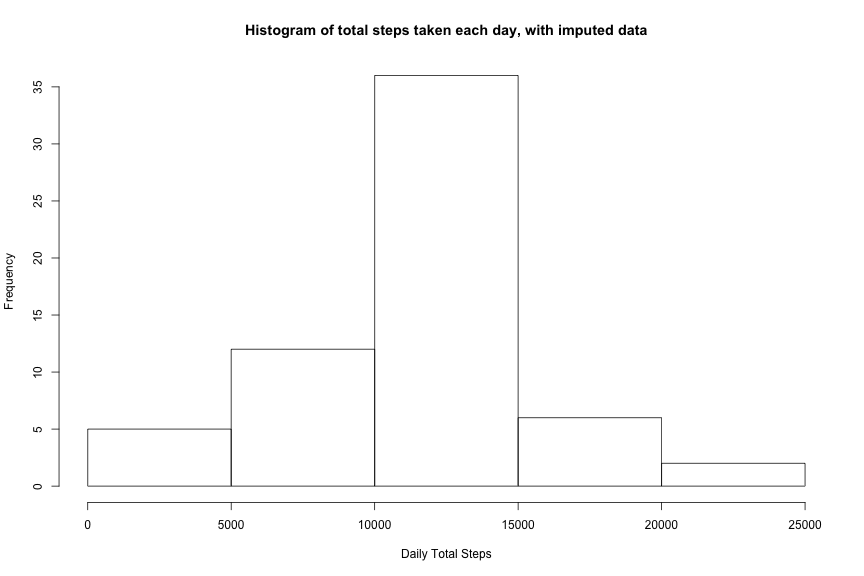

```r
new_daily_total<-data.table(new_movement_data)[,list(new_daily_steps=sum(steps,na.rm=TRUE)),by=date]
hist(new_daily_total$new_daily_steps,main='Histogram of total steps taken each day, with imputed data',xlab='Daily Total Steps')
```

```r
new_mean_daily<-mean(new_daily_total$new_daily_steps)
new_median_daily<-median(new_daily_total$new_daily_steps)
print(paste("The mean of the total number of steps taken per day is",round(new_mean_daily,digits=2)))
```

```
## [1] "The mean of the total number of steps taken per day is 10766.19"
```

```r
print(paste("The median of the total number of steps taken per day is",round(new_median_daily,digits=2)))
```

```
## [1] "The median of the total number of steps taken per day is 10766.19"
```

##Are there differences in activity patterns between weekdays and weekends?

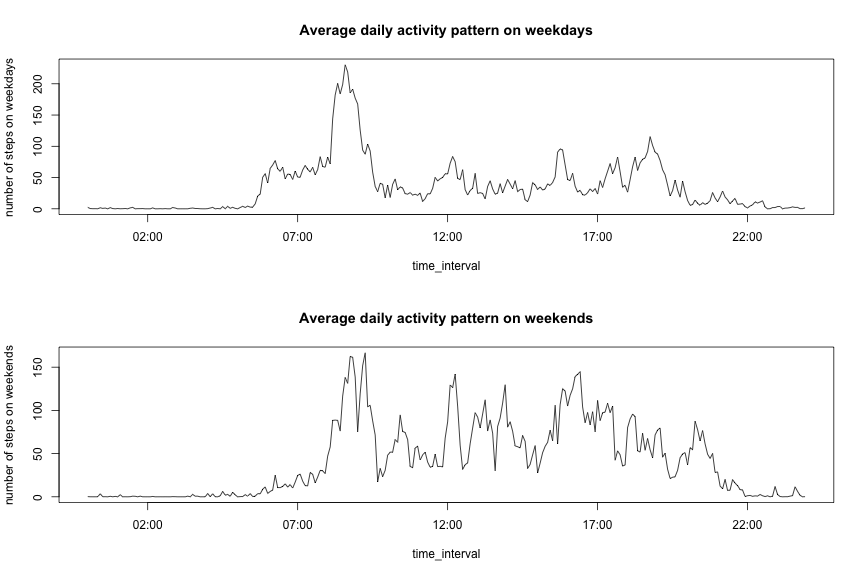

```r
new_movement_data$dow<-weekdays(as.Date(new_movement_data$date))
new_movement_data$weekday<-ifelse(new_movement_data$dow %in% c('Saturday','Sunday'),'weekend','weekday')
wkday<-new_movement_data[new_movement_data$weekday=='weekday',]
weekend<-new_movement_data[new_movement_data$weekday=='weekend',]
wkday_itv_avg<-data.table(wkday)[,list(interval_avg_steps=mean(steps,na.rm=TRUE)),by=interval]
wkend_itv_avg<-data.table(weekend)[,list(interval_avg_steps=mean(steps,na.rm=TRUE)),by=interval]
par(mfrow=c(2,1))
plot(x=time_interval,y=wkday_itv_avg$interval_avg_steps,type='l',ylab='number of steps on weekdays',main="Average daily activity pattern on weekdays")
plot(x=time_interval,y=wkend_itv_avg$interval_avg_steps,type='l',ylab='number of steps on weekends',main="Average daily activity pattern on weekends")
```